# Logistic Regression

A Powerful Tool for Classification  
Academic Year 1447  
Term 1  
Dr. Jomana Bashatah  
Slides adapted from Casten Lange

## Basics of Logistic Regression

Classification Algorithm:

- **Two categories for the outcome variable (analysed in what follows):** e.g. Unemployed true or false
- Multiple categories for the outcome variable (not covered here)
  - unordered logistic regression
  - ordered logistic regression »

## A Mock-Up Example to Introduce the Idea

- After a few years past graduation, 11 college friends reunite
- Financially, some are doing very well and others are doing just OK
- The table below shows the yearly salaray (in thousands of dollars) and if they own a yacht (`Yacht = 1`) or not (`Yacht = 0`)
  - Note: the table only contains 10 rows as one of them (Razan) has not arrived yet. We will talk about Razan later on

Income and Yacht Ownership

| Name | Income | Yacht |
| --- | --- | --- |
| Alanoud | 45 | 1 |
| Ghada | 50 | 0 |
| Maha | 55 | 0 |
| Raghad | 60 | 0 |
| Shahad | 67 | 0 |
| Layan | 250 | 1 |
| Munerah | 280 | 1 |
| Lama | 320 | 1 |
| Rema | 370 | 1 |
| Layan | 500 | 1 |

## Using OLS is a Tempting (but bad) Idea

[interactive chart not shown]

## Using OLS is a Tempting (but bad) Idea

- An obvious - but sup-optimal as we will see later on - approach is a linear regression
- Use OLS to find a regression line with slope $\mathit{beta_1}$ and intercept $\mathit{beta_2}$ that best approximates the data (minimizing the `MSE`)

[interactive chart not shown]

## Linear Function for Binary Classification

- The underlying regression assigns continuous numbers to different income levels to different income levels rather than assign categorical values such as 1 (“yacht owner: yes”) or 0 (“yacht owner: no”)
- Therefore, we interpret the continuous predictions from the regression as `probabilities`for being a yacht owner ($\mathit{Prob_i}$)
- The underlying probability is called the `Linear Probability Model (LPM)`
- The prediction equation would be $\mathit{prob_i}$ = $\mathit{\beta_1}$ $\mathit{Inc_i}$ + $\mathit{beta_2}$
- The prediction equation from the LPM can be used to predict the probability of a person being a yacht owner based on their income.
  - Whenever the outcome variable (the probability) is greater than 0.5, we predict “yacht owner: yes”, otherwise, “yacht owner: no”

## Example Calculations

$\mathit{prob_i}$ = $\mathit{0.0023}$ $\mathit{Inc_i}$ + $\mathit{0.1418}$

## Quick Way to Find a Decision Boundary

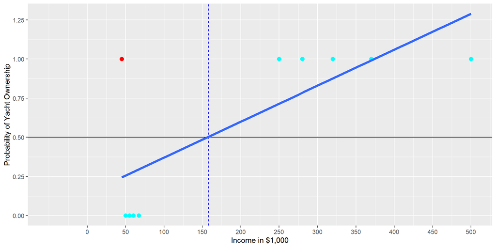

*1.* Find the intersection point between the prediction line and the horizontal 0.5 probability line.

*2.* Draw a vertical line through the intersection point. This line is called a **decision boundary**.

*3.* All incomes left of the *decision boundary* (income smaller than 158) are predicted as “no”. All incomes right of the *decision boundary* (income greater than 158) are predicted as “yes”.

## Why OLS for Classification is a Bad Idea

[interactive chart not shown]

Note, incomes > $370,000 are predicted with a probability > 100% to be yacht owners(?)

A similar problem can occur with negative probabilities!

## A Step-Function as an Alternative to OLS

- If we are wiling to give up the linearity requirement, we can avoid these problems
- A non-linear prediction line can bend for greater income values downwards and thus avoid exceeding 1.
- For small income values, the prediction line can bend upwards and thus avoid falling below 0.

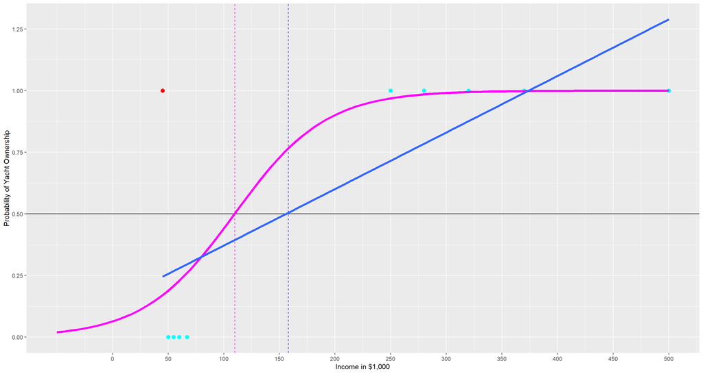

## Popular Step-Functions (Sigmoid Function)

- Since the curve looks like a step of a staircase (first horizontal, then almost vertical, and finally horizontal again), these types of curves are called step-function.
  - Scientifically, they are called `sigmoid functions`
- Sigmoid Functions Include
  - The **Hyperbolic Tangent function**.
  - The **Arc Tangent function**.
  - The **Logistic function** .

## The Logistic Function

- The **Logistic function** (confusingly sometimes also called the *sigmoid function*):

$$y_i=\frac{1}{1+e^{-x_i}}$$

We use: $y_i=P^{rob}_{yes,i}$ and $x_i=\beta_1 Inc_i+\beta_2$ which gives us:

$$P^{rob}_{yes,i}=\frac{1}{1+e^{-(\beta_1 Inc_i+\beta_2)}}$$

$\beta_1$ and $\beta_2$ change slope and position

$\beta_2$ shifts the curve horizontally

$\beta_1$ determines the steepness of the step

See: [Try it yourself](https://econ.lange-analytics.com/calcat/logisticregr)

## What Makes the Logistic Function so Special?

### compared to other sigmoid (step) functions

**Time for some mathematical magic:**

Logistic function $P^{rob}_{yes,i}$ := probability for positive event (e.g. yacht ownership: yes):

$$P^{rob}_{yes,i}=\frac{1}{1+e^{-(\beta_1\cdot x_i+\beta_2)}}$$

. . .

Take the inverse on both sides of the equation:

$$\frac{1}{P^{rob}_{yes,i}}=1+e^{-(\beta_1\cdot x_i+\beta_2)}$$
. . .

Subtract 1 on both sides:

$$\frac{1}{P^{rob}_{yes,i}}-1=e^{-(\beta_1\cdot x_i+\beta_2)}$$
. . .

Consider that $-1=-\frac{P^{rob}_{yes,i}}{P^{rob}_{yes,i}}$ and substitute $-1$ accordingly, we get after simplification:

$$\frac{1-P^{rob}_{yes,i}}{P^{rob}_{yes,i}}=e^{-(\beta_1\cdot x_i+\beta_2)}$$
. . .

$1-P^{rob}_{yes,i}$ equals by definition $P^{rob}_{no,i}$:

$$\frac{P^{rob}_{no,i}}{P^{rob}_{yes,i}}=e^{-(\beta_1\cdot x_i+\beta_2)}$$
. . .

Take again the inverse on both sides:

$$\frac{P^{rob}_{yes,i}}{P^{rob}_{no,i}}=e^{\beta_1\cdot x_i+\beta_2}$$
. . .

Take the logarithm on both sides:

$$\ln\left (\frac{P^{rob}_{yes,i}}{P^{rob}_{no,i}}\right )=\beta_1\cdot x_i+\beta_2$$

## One More Step — Odds vs Probabilties

- The fraction of the yes/no probabilities can be interpreted as $Odds$ as they are often used in betting.
- Example: The probability of getting two heads when flipping two coins is is $P^{rob}_{yes,i}=0.25$.
- Consequently, the probability of **not** getting two heads when flipping two coins is $P^{rob}_{no,i}=0.75$.
- $Odds$ for 2 Heads compared to **not** 2 heads is 1 to 3 or 33%:

$$O^{dds}=\frac{P^{rob}_{yes,i}}{P^{rob}_{no,i}}=\frac{0.25}{0.75}=\frac{1}{3}=0.33$$

## Interpretation of the $\beta s$: Yacht Ownership

$$\ln(O^{dds})=\ln\left (\frac{P^{rob}_{yes,i}}{P^{rob}_{no,i}}\right )=0.02\cdot Inc_i+(-2.7)$$

Model results after running and printing the workflow():

```r
# The workflow WFYachts had been created before and
# DataTest were fitted to the workflow.
print(WFYachts)
```

```
══ Workflow [trained] ══════════════════════════════════════════════════════════
Preprocessor: Recipe
Model: logistic_reg()

── Preprocessor ────────────────────────────────────────────────────────────────
0 Recipe Steps

── Model ───────────────────────────────────────────────────────────────────────

Call:  stats::glm(formula = ..y ~ ., family = stats::binomial, data = data)

Coefficients:
(Intercept)       Income
   -2.68660      0.02448

Degrees of Freedom: 9 Total (i.e. Null);  8 Residual
Null Deviance:      13.46
Residual Deviance: 5.654    AIC: 9.654
```

## Interpretation of the $\beta s$: Yacht Ownership

$$\ln(O^{dds})=\ln\left (\frac{P^{rob}_{yes,i}}{P^{rob}_{no,i}}\right )=0.02\cdot Inc_i+(-2.7)$$

- If income increases by 1 ($1,000) the logarithm of the odds increases by 0.02.
- Since change of a logarithm is a relative change (**percentage**):

If income increases by 1 ($1,000) the odds increases by 2% (0.02). (careful with the results because data were made up and N is too small!)

## Confusion Matrix

Note, in the mockup we did not create training and testing data. Therefore, we use DataYachts (the data we used to fit/train the workflow) here. This is not a proper methodology but good enough for the mock-up:

```r
DataYachtsWithPred=augment(WFYachts, new_data=DataYachts)
conf_mat(DataYachtsWithPred, truth=Yacht, estimate=.pred_class)
```

```
          Truth
Prediction 0 1
         0 4 1
         1 0 5
```

## Real World Churn Analysis with Logistic Regression — the Data

We use data (7,043 customers) of the fictional telecommunication company *TELCO*, generated by *IBM* for training purposes:

- The outcome variable $Churn$ indicates, if a customer departed within the last month ($Churn=Yes$) or not ($Churn=No$).
- Predictor variables contain:
  - Customers’ $Gender$ ($Female$ or $Male$),
  - Customers’ $SeniorCitizen$ status ($0$ for no or $1$ for yes),
  - Customers’ $Tenure$ with *TELCO* (month of membership), as well as
  - Customers’ $MonthlyCharges$ (in US-$).

## Real World Churn Analysis with Logistic Regression — the Data

```r
DataChurn=import("https://raw.githubusercontent.com/jomanab-cloud/ISE351-25-Presentations/d02e876360b32dd91d952f78791323d90f0a0395/TelcoChurnData.csv") %>%
  clean_names("upper_camel") %>%
  select(Churn,Gender,SeniorCitizen,Tenure,MonthlyCharges) %>%
  mutate(Churn=factor(Churn, levels=c("Yes","No")))
head(DataChurn)
```

```
  Churn Gender SeniorCitizen Tenure MonthlyCharges
1    No Female             0      1          29.85
2    No   Male             0     34          56.95
3   Yes   Male             0      2          53.85
4    No   Male             0     45          42.30
5   Yes Female             0      2          70.70
6   Yes Female             0      8          99.65
```

## Real World Churn Analysis with Logistic Regression

### — Do it yourself —

Create the Churn analysis with logistic regression. Click on the link in the footer to get an R-script with a skeleton for the analysis.

[Download: 09-LogRegrExerc100.Rmd](https://github.com/jomanab-cloud/ISE351-25-Presentations/blob/181fc54541f425aa7fc95094bc4c4665ded6af2c/09-LogRegrExerc100.Rmd)

## Results from Churn Analysis with Logistic Regression

Confusion Matrix:

|  | Yes | No |
| --- | --- | --- |
| Yes | 239 | 150 |
| No | 322 | 1403 |

Accuracy:

| .metric | .estimator | .estimate |
| --- | --- | --- |
| accuracy | binary | 0.7767266 |

Sensitivity:

| .metric | .estimator | .estimate |
| --- | --- | --- |
| sensitivity | binary | 0.426025 |

Specificity:

| .metric | .estimator | .estimate |
| --- | --- | --- |
| specificity | binary | 0.9034127 |

**Hint:** What do the column sums of the confusion matrix tell you?

## Problem: Unballanced Training Data

| Churn | n |
| --- | --- |
| Yes | 1308 |
| No | 3621 |

**Majority Class:** $Churn=No$ has 3621 observations in the training dataset.

**Minority class** $Churn=Yes$ has 1308 observations in the training dataset.

## What can we do?

| Churn | n |
| --- | --- |
| Yes | 1308 |
| No | 3621 |

- **Downsampling:** Randomly **delete observations from majority class** until ratio of the observations from the majority and the minority class reaches the desired ratio (e.g., 1:1).
- **Upsampling:** In simplest version, **creates new observations for the minority class** by copying randomly chosen observations from the minority class until the ratio of the observations from the majority and the minority class reaches the desired ratio (e.g., 1:1).
- Often, a combination of *downsampling* and *upsampling* is performed.

## Performing Down-Sampling with `step_downsample()`

You need to add the R package `themis`. Then in your script, you can add `step_downsample(Churn)` to the recipe (don’t forget to execute the following command lines again). As a reminder our original DataTrain had 4,929 observations, $Churn_{Yes}=1308$, $Churn_{No}=3621$:

```r
library(themis)
RecipeChurn=recipe(Churn ~ ., data=DataTrain) %>%
  step_naomit() %>%
  step_dummy(Gender) %>%
  step_downsample(Churn)

 # you do not need to do the following steps.
# They just allow to display the count() for the training data
ExtractedDataTrain=juice(RecipeChurn %>% prep())
kbl(count(ExtractedDataTrain, Churn))
```

| Churn | n |
| --- | --- |
| Yes | 1308 |
| No | 1308 |

Note, the number of observations has decreased by 2313. This is an information loss!

## Performing Up-Sampling with `step_upsample()`

You need to add the R package `themis`. Then in your script, you can add `step_upsample(Churn)` to the recipe (don’t forget to execute the following command lines again). As a reminder our original DataTrain had 4,929 observations, $Churn_{Yes}=1308$, $Churn_{No}=3621$:

```r
library(themis)
RecipeChurn=recipe(Churn ~ ., data=DataTrain) %>%
  step_naomit() %>%
  step_dummy(Gender) %>%
  step_upsample(Churn)

 # you do not need to do the following steps.
# They just allow to display the count() for the training data
ExtractedDataTrain=juice(RecipeChurn %>% prep())
kbl(count(ExtractedDataTrain, Churn))
```

| Churn | n |
| --- | --- |
| Yes | 3621 |
| No | 3621 |

Note, the number of observations has increased by 2313. The information in the dataset has not increased!

As a reminder our original DataTrain had 4,929 observations, $Churn_{Yes}=1308$, $Churn_{No}=3621$:

```r
library(themis)
RecipeChurn=recipe(Churn ~ ., data=DataTrain) %>%
  step_naomit() %>%
  step_dummy(Gender) %>%
  step_upsample(Churn)

 # you do not need to do the following steps.
# They just allow to display the count() for the training data
ExtractedDataTrain=juice(RecipeChurn %>% prep())
kbl(count(ExtractedDataTrain, Churn))
```

| Churn | n |
| --- | --- |
| Yes | 3621 |
| No | 3621 |

[Download: 09-LogRegrExerc200.Rmd](https://github.com/jomanab-cloud/ISE351-25-Presentations/blob/181fc54541f425aa7fc95094bc4c4665ded6af2c/09-LogRegrExerc200.Rmd)